# 梁伟煌

```python
1.通过input输入一个字符，并判断它的类型，然后输出它是什么类型。 可以无限次输入，直至自己输入‘退出’才会结束。 例如：
* [1,24] --->print('您输入的是列表')
* Csd --->print('您输入的是字符串')
```

```python
while True:
    try:
        x=input('请输入一个字符:')
        if x=='退出':
            print('终止程序')
            break
        else:
            x=eval(x)
            if type(x)==int:
                print('您输入的是整数')
            elif type(x)==float:
                print('您输入的是浮点型')
            elif type(x)==list:
                print('您输入的是列表')
            elif type(x)==set:
                print('您输入的是集合')
            elif type(x)== tuple:
                print('您输入的是元组')
            elif type(x)==dict:
                print('您输入的是字典')

    except:
        print("您输入的是字符串>")
```

2.将字符串 去重并从小到大排序输出， 排序可用sorted()。 例如

- s = “ajldjlajfdljfddd”---->”adfjl”。

```python
s = 'ajldjlajfdljfdddqm'
sorted(set(s))
```

```
['a', 'd', 'f', 'j', 'l', 'm', 'q']
```

3.根据num.txt，设计函数，计算每个小列表里面的平均人数。 例如：

- ['1000人以上'] ----> 1000
- ['50-150人'] ----> （150+50）/2 = 100,
- [''] ----> 0
- 最终结果保存在列表中，例如：[['50-150人'], [''],['1000人以上'] ] --> [100,0,1000,...]

```python
avg=[]
with open('../data/num.txt','r') as f:
    person=f.read()
x=person.replace('人','').replace('以上','').replace(']','').replace('[','').replace('少于','').replace(' ','').replace(',','')
x=x.split('"')
for i in x:
    if i=="":
        avg.append(0)
    else:
        i=i.replace("'",'')
        for j in i:
            j=i.split('-')
            if len(j)==2:
                j=(eval(j[1])+eval(j[0]))/2
                avg.append(j)
            else:
                j=eval(j[0])
                avg.append(j)
avg
```

```
[0,
 10000,
 10000,
 10000,
 10000,
 10000,
 0,
 100.0,
 100.0,
 100.0,
 100.0,
 100.0,
 100.0,
 0,
 10000,
 10000,
 10000,
 10000,
 10000,
 0,
 325.0,
 325.0,
 325.0,
 325.0,
 325.0,
 325.0,
 325.0,
 0,
 10000,
 10000,
 10000,
 10000,
 10000,
 0,
 750.0,
 750.0,
 750.0,
 750.0,
 750.0,
 750.0,
```

[output cut: 946 more lines]

```
 7500.0,
 7500.0,
 0,
 750.0,
 750.0,
 750.0,
 750.0,
 750.0,
 750.0,
 750.0,
 750.0,
 0,
 325.0,
 325.0,
 ...]
```

定义了一个 Car 类，它有 brand、model 和 year 属性，表示汽车的品牌、型号和制造年份。还有 speed 属性表示当前车速。

- 类中定义三个方法：accelerate（加速）、brake（刹车）和 get_speed（获取速度）。
- accelerate可以输入加速参数increment表示加速了多少，输出经过加速后汽车的速度
- brake可以输入参数decrement表示减速了多少，输出减速后的汽车速度
- get_speed可以获取当前汽车的速度

```python
class Car:
    def __init__(self,brand,model,year,speed):
        self.brand=brand
        self.model=model
        self.year=year
        self.speed=speed
    def accelerate(self,js):
        if type(js)!=float and type(js)!=int:
            print("请输入正确的速度")
        else:
            self.speed+=js
            print(f'加速了{js}km/h，当前车速为{self.speed}km/h')
    def brake(self,sc):
        if type(sc)!=float and type(sc)!=int:
            print("请输入正确的速度")
        else:
            self.speed-=sc
            if self.speed <=0:
                self.speed=0
            else:
                print(f'减速了{sc}km/h,当前车速为{self.speed}km/h')
    def get_speed(self):
        print(f"当前车速为{self.speed}km/h")
car=Car(brand='byd',model='no.1',year='2022',speed=200)
```

```python
car.accelerate(30.1)
car.brake(20)
car.get_speed()
```

[output not shown]

5.内容判断

- a = [1,2,3] 与 b = [3,2,1]，两个列表中的内容是一样的，怎么判断出来？
- 提示：集合

```python
def same(list_1, list_2):
    list_1 = set(list_1)
    list_2 = set(list_2)
    result = list_1.difference(list_2)
    if len(result) == 0:
        print('两个列表内容相同')
    else:
        print('两个列表内容不相同')

    return result

same([1, 2, 3, 1,5], [3, 2, 1, 1, 3])
```

[output not shown]

```
{5}
```

6.（os、shutil模块的内容） 创建一个函数copy_directory，传入两个参数source_dir、destination_dir分别表示源文件夹和目标文件夹。 *该函数作用是判断目标文件夹是否存在，如果不存在则新建，如果存在则把源文件夹下所有的内容复制到目标文件夹里面。

```python
import os
import shutil

def copy_directory(source_dir, destination_dir):
    if not os.path.exists(destination_dir):             #判断目标文件夹是否存在
        os.makedirs(destination_dir)                    #如果不存在则创建目标文件夹

    tree = os.listdir(source_dir)                       #将源文件夹的子文件和子文件夹查询出来保存在tree中
 #下面是网上抄的
    for item in tree:
        source_item = os.path.join(source_dir, item)             #将名称与源文件路径拼接
        destination_item = os.path.join(destination_dir, item)   #将名称与目标路径拼接

        if os.path.isfile(source_item):
            shutil.copy2(source_item, destination_item)   #判断是否为文件，如果是则用copy2复制到目标文件夹
```

```python
copy_directory('../data/','../data1')
```

7.（有难度，可以不做）python程序设计思维，井字棋游戏：构建棋盘3X3的棋盘，X和O分别下棋，当三个棋连成线时胜出。已在board中给出棋盘的位置以及初始的字符串,并可以通过print_board()打印每次下棋后的棋盘结果

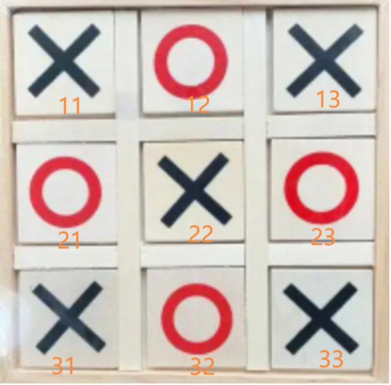

- A. 11，12，32等表示棋盘的位置，通过input提示X和O输入下棋的位置
- B. 对输入的位置判断是否合法，只能是11，12，13，21，22，23，31，32，33几个位置，并且位置被占用之后不能重新下棋，例如：位置11被X占用之后，O不能再占用11。
- C.每走一步判断谁输谁赢（三个棋连成线则赢，思考该怎么完成这个判断过程？），直到一方胜出或者走完9步为止则游戏结束。

```python
win = [{11, 12, 13}, {21, 22, 23}, {31, 32, 33}, {11, 21, 31}, {12, 22, 32}, {13, 23, 33}, {11, 22, 33}, {13, 22, 31}]#所有胜利的组合
local = {11, 12, 13, 21, 22, 23, 31, 32, 33}  # 所有位置坐标，集合类型
p1 = []  # 空列表，用于存放玩家1的坐标
p2 = []  # 空列表，用于存放玩家2的坐标
def board():
    for i in range(3):
        print('|',end='')
        for j in range(3):
            if (i+1)*10+j+1 in p1:
                print('X',end='|')
            elif (i+1)*10+j+1 in p2:
                print('O', end='|')
            else:
                print(' ',end="|")
        print('')
        print('-'*7)
def player(p, play):
    while 1==1:
        x = []
        try:
            locate = eval(input(f"请玩家{play}输入位置"))
        except:
            print('您输入的不是坐标')
            continue
        x.append(locate)
        if len(set(x) & local) == 0:
            print('请输入正确的位置')
            continue
        elif locate not in p1 and locate not in p2:
            p.append(locate)
            print()
            break
        else:
            print("该位置已有棋子了，请重新放置")
            continue
for i in range(0, 9):
    if i % 2 == 0:
        player(p1, 1)
    else:
        player(p2, 2)
    board()
    for k in win:
        if len(set(p1) & k) == 3:
            print('游戏结束，玩家1赢了')
            p1.clear()
            break
        elif len(set(p2) & k) == 3:
            print('游戏结束，玩家2赢了')
            break
    else:
        continue
    break
if len(p1) + len(p2) == 9:
    print('游戏结束，平局')
```

```
请玩家1输入位置11

|X| | |
-------
| | | |
-------
| | | |
-------
请玩家2输入位置12

|X|O| |
-------
| | | |
-------
| | | |
-------
请玩家1输入位置13

|X|O|X|
-------
| | | |
-------
| | | |
-------
请玩家2输入位置31

|X|O|X|
-------
| | | |
-------
|O| | |
-------
请玩家1输入位置32

|X|O|X|
-------
| | | |
-------
|O|X| |
-------
```

[output cut: 18 more lines]

```
|X|O|X|
-------
|O|X| |
-------
|O|X|O|
-------
请玩家1输入位置23

|X|O|X|
-------
|O|X|X|
-------
|O|X|O|
-------
游戏结束，平局
```